# Monte Carlo Methods

Integration, Inference, and the Bootstrap

ISI-BUDS 2026

2026-06-29

## Where we are

You just reviewed **probability** and learned to **generate data** from a distribution using its inverse CDF. You can now produce as many draws $X_1, X_2, \dots$ from a model as you like.

**Today: put that simulation power to work.** If we can *sample*, we can *compute* expectations, integrals, error bars, coverage, $p$-values ,etc. without analtyic forms.

This is the idea behind **Monte Carlo methods**.

The engine underneath everything today is one theorem you already know: the Law of Large Numbers. Averages of samples converge to expectations.

## Today’s plan

**Part 1** — Expectation & the Law of Large Numbers

**Part 2** — Monte Carlo integration & error

**Part 3** — Importance sampling

**Part 4** — Monte Carlo for inference

**Part 5** — The bootstrap

**Part 6** — Wrap-up

Throughout: short math, then a live R demo. The estimators are a few lines of code each.

# Part 1 — Expectation & the LLN

CORE TOOLS

## Expectation and moments

- For a **discrete** random variable $X$:
  $$E[g(X)]=\sum_{k} g(x_k)\,P(X=x_k)$$
  - 1st moment $g(x)=x$: $\;E(X)=\sum_k x_k P(X=x_k)$
  - 2nd moment $g(x)=x^2$: $\;E(X^2)=\sum_k x_k^2 P(X=x_k)$
- For a **continuous** random variable $X$:
  $$E[g(X)]=\int_{-\infty}^{\infty} g(x)\,f(x)\,dx$$

An expectation is just a **weighted average** of $g(x)$, weighted by how likely each $x$ is.

## Example: mean of an exponential

Suppose $X \sim \text{Exp}(\lambda)$ with pdf $f(x)=\lambda e^{-\lambda x}\mathbf{1}_{\{x \ge 0\}}$, rate $\lambda > 0$. Derive $E(X)$.

$$E(X) = \int_{-\infty}^{\infty} x f(x)\,dx = \int_{0}^{\infty} x\,\lambda e^{-\lambda x}\,dx
= \frac{1}{\lambda}\quad\text{(integration by parts).}$$

So for $\lambda = 0.5$ we expect $E(X) = 2$. In a moment we will recover it by *averaging samples* instead of integrating.

## Two facts we will use frequently

**Expectations are linear operators.** For random variables $X_1,\dots,X_n$ and constants $a_1,\dots,a_n$:
$$E\!\left[\sum_{i=1}^n a_i X_i\right] = \sum_{i=1}^n a_i E(X_i).$$

**Variance are not**, but scaling and independence help. Recall $\text{Var}(aX)=a^2\text{Var}(X)$, and if $X_1,\dots,X_n$ are **independent**,
$$\text{Var}\!\left(\sum_{i=1}^n a_i X_i\right)=\sum_{i=1}^n a_i^2\,\text{Var}(X_i).$$

Apply both to a sample mean $\bar X_n=\frac1n\sum_i X_i$ of iid draws:

$E(\bar X_n)=\mu$ and $\text{Var}(\bar X_n)=\sigma^2/n$.

**Averaging keeps the target and shrinks the noise.**

## The Strong Law of Large Numbers

Let $X_1,X_2,\dots$ be iid with $\mu=E(X_i)<\infty$. Then
$$\frac{1}{n}\sum_{i=1}^n X_i \;\longrightarrow\; \mu \qquad \text{as } n\to\infty.$$

The **empirical average** of iid draws converges to the **theoretical expectation**.

## Demo: watch the LLN happen — the code

```r
library(ggplot2)
set.seed(1)
n        <- 2000
x        <- rexp(n, rate = 0.5)          # E(X) = 1/0.5 = 2
run_mean <- cumsum(x) / seq_len(n)       # running average after each draw

p_lln <- ggplot(data.frame(n = seq_len(n), mean = run_mean), aes(n, mean)) +
  geom_line(color = blue, linewidth = 0.7) +
  geom_hline(yintercept = 2, color = orange, linetype = "dashed", linewidth = 1) +
  labs(x = "number of samples", y = "running average",
       title = "Running mean of Exp(0.5) converges to E(X) = 2") +
  theme_acic()
```

Draw 2000 exponentials, then track the running average after each draw. The figure is stored in `p_lln` — shown on the next slide.

## Demo: watch the LLN happen — the result

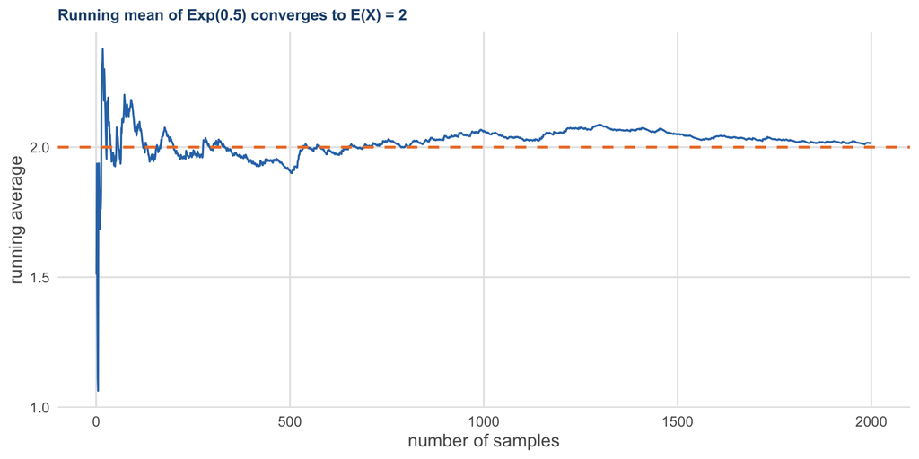

Each point is the average of the first $n$ draws. It bounces around early, then settles onto the truth (orange line). That settling *is* the Law of Large Numbers — more samples, tighter to the truth (gradually, like $1/\sqrt{n}$).

# Part 2 — Monte Carlo Integration

SAMPLING TO COMPUTE

## The core idea

We want $E[h(X)] = \int h(x) f(x)\,dx$ (continuous) or $\sum_k h(x_k) p(x_k)$ (discrete), where $X \sim f$.

**Idea.** The integral *is* a weighted average. Replace it with a **sample average**: draw $X_1,\dots,X_n \sim f$ and compute
$$\bar h_n = \frac{1}{n}\sum_{i=1}^n h(X_i).$$

If $E[h(X)] < \infty$, the SLLN guarantees
$$\bar h_n \;\longrightarrow\; E[h(X)].$$

We never did the integral. We just sampled and averaged, but the SLLN tells us we can approximate $E[h(X)]$ well with $\bar h_n$.

## A probability is just an expectation

Let $A$ be an event and $\mathbf{1}_A$ its indicator. Then $\mathbf{1}_A \sim \text{Bernoulli}(p)$ with $p=P(A)$, so
$$E(\mathbf{1}_A) = 1\cdot p + 0\cdot(1-p) = p = P(A).$$

To estimate **any probability**, average the indicator over samples:
$$\hat p = \frac{1}{n}\sum_{i=1}^n \mathbf{1}\{X_i \in A\}.$$
That is just “the fraction of samples that landed in $A$.”

## Demo: estimate a tail probability — the code

```r
library(ggplot2)
set.seed(2)
c_val <- 2
N     <- 50000
z     <- rnorm(N)                       # draw from N(0,1)
hits  <- as.numeric(z > c_val)          # indicator 1{Z > c}
run_p <- cumsum(hits) / seq_len(N)      # running Monte Carlo estimate of P(Z > c)
truth <- pnorm(c_val, lower.tail = FALSE)

c(mc_estimate = mean(hits), exact = truth)
```

```
mc_estimate       exact
 0.02350000  0.02275013
```

We estimate $P(Z>2)$ — a number that needs the normal CDF — by counting the fraction of standard-normal draws above 2. The estimate matches the exact value; the convergence plot is next.

## Demo: estimate a tail probability — the result

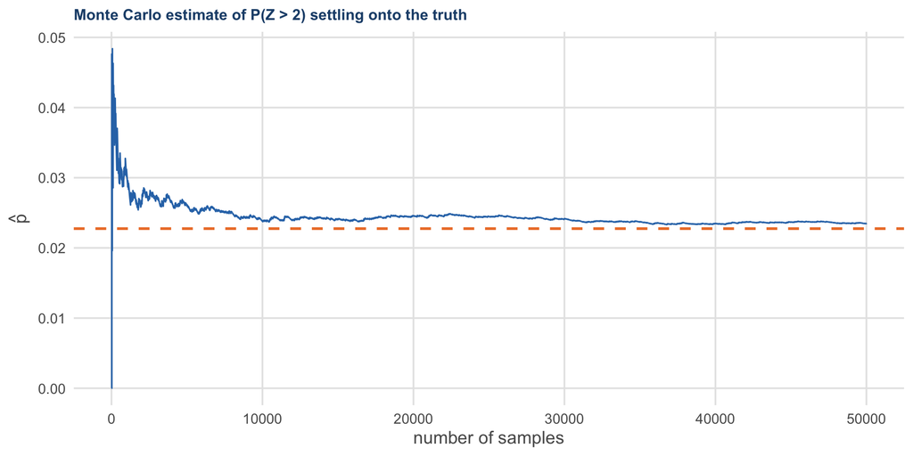

The running estimate (fraction of draws above 2) wanders early, then settles onto the exact $P(Z>2)\approx 0.0228$ (orange line).

## How accurate is $\bar h_n$? The CLT

Suppose $X_1,\dots,X_n$ are iid with mean $\mu$ and $0 < \sigma^2 < \infty$. Then for large $n$,
$$\frac{\sqrt{n}\,(\bar X_n - \mu)}{\sigma} \;\approx\; N(0,1),
\qquad\text{i.e.}\qquad \bar X_n \;\approx\; N\!\Big(\mu,\ \tfrac{\sigma^2}{n}\Big).$$

The CLT tells us not just *that* $\bar h_n \to E[h(X)]$, but **how fast**: the spread of the estimate shrinks like $\sigma/\sqrt{n}$.

## The Monte Carlo error bar

Use $\bar h_n=\frac1n\sum_i h(x_i)$ to estimate $E[h(X)]$. By the CLT, $\bar h_n \approx N\!\big(\mu,\ s_n^2/n\big)$ where
$$s_n^2 = \frac{1}{n-1}\sum_{i=1}^n \big(h(x_i)-\bar h_n\big)^2 \quad\text{(sample variance).}$$

An approximate **95% confidence interval** for the quantity we are estimating:
$$\bar h_n \;\pm\; 1.96\,\frac{s_n}{\sqrt{n}}.$$
The term $s_n/\sqrt{n}$ is the **Monte Carlo standard error** — report it with every estimate.

## Demo: estimate with an error bar

```r
set.seed(3)
n   <- 20000
x   <- rexp(n, rate = 0.5)              # estimate E(X) for Exp(0.5); truth = 2
hbar <- mean(x)                         # Monte Carlo estimate
se   <- sd(x) / sqrt(n)                 # Monte Carlo standard error
ci   <- hbar + c(-1.96, 1.96) * se      # approximate 95% CI

round(c(estimate = hbar, se = se, ci_lo = ci[1], ci_hi = ci[2], truth = 2), 4)
```

```
estimate       se    ci_lo    ci_hi    truth
  2.0062   0.0142   1.9784   2.0341   2.0000
```

The estimate sits close to 2, the standard error reports the uncertainty, and the interval comfortably contains the truth. **Quadruple $n$ and the SE roughly halves.**

# Part 3 — Importance Sampling

WHEN NAIVE SAMPLING FAILS

## When naive Monte Carlo struggles

To estimate $P(Z > c)$ we averaged $\mathbf{1}\{Z_i > c\}$. What happens as $c$ grows?

As $c$ increases, $P(Z>c)$ becomes very small. Almost every draw gives $\mathbf{1}\{Z_i>c\}=0$. For $c=4.5$, $P(Z>c)\approx 3\times10^{-6}$, so you might draw **millions** of samples and still see *zero* hits.

The estimator is unbiased but its variance, relative to the tiny thing we are estimating, is enormous. We need to sample strategically.

## Importance sampling: change where you sample

Don’t sample from $f$; sample from an easier $g$ and reweight:
$$E_f[h(X)] = \int h(x) f(x)\,dx
= \int h(x)\frac{f(x)}{g(x)}\,g(x)\,dx
= E_g\!\left[h(Y)\frac{f(Y)}{g(Y)}\right],\quad Y\sim g.$$

Draw $Y_1,\dots,Y_n \sim g$ and average the **reweighted** values:
$$E_f[h(X)] \approx \frac{1}{n}\sum_{i=1}^n \underbrace{\frac{f(Y_i)}{g(Y_i)}}_{w_i}\,h(Y_i).$$
The $w_i$ are the **importance weights** — they correct for sampling from the “wrong” distribution.

## Example: the tail of $N(0,1)$

Target: $P(Z > c) = E_f[\mathbf{1}\{Z>c\}]$ with $f=\phi$, the standard normal density.

Sample instead from a **shifted exponential** sitting at $c$: $\;g(y)=e^{-(y-c)}\mathbf{1}_{\{y>c\}}$.

Every draw lands in the region $\{y>c\}$ — no wasted samples. The estimator becomes
$$\hat\mu = \frac{1}{n}\sum_{i=1}^n \frac{\phi(Y_i)}{g(Y_i)}, \qquad Y_i \sim g.$$

## Demo: naive vs importance sampling

```r
set.seed(4)
c_val <- 4.5
n     <- 50000
truth <- pnorm(c_val, lower.tail = FALSE)        # ~ 3.4e-06

# Naive Monte Carlo: fraction of N(0,1) draws above c
z_naive   <- rnorm(n)
est_naive <- mean(z_naive > c_val)

# Importance sampling: draw from shifted Exp(1) at c, reweight by phi/g
y      <- c_val + rexp(n, rate = 1)              # g(y) = exp(-(y - c)), y > c
w      <- dnorm(y) / exp(-(y - c_val))           # importance weights
est_is <- mean(w)
se_is  <- sd(w) / sqrt(n)

round(c(truth = truth, naive = est_naive,
        imp_samp = est_is, is_se = se_is), 8)
```

```
   truth    naive imp_samp    is_se
3.40e-06 0.00e+00 3.35e-06 2.00e-08
```

Naive MC often returns **exactly 0** (no draw reached 4.5). Importance sampling nails the tiny probability *and* reports a meaningful standard error — from the same number of samples.

## Discussion: which estimator do you trust?

**Pause.** You run a simulation and get two estimates of the same rare probability:

- Estimator A: $\hat p = 0$ from **$10^6$** naive draws.
- Estimator B: $\hat p = 3.1\times10^{-6}$ with SE $2\times10^{-7}$ from $5\times10^4$ importance-sampling draws.

Which do you report, and why? What does $\hat p = 0$ actually tell you?

$\hat p = 0$ does not mean the event is impossible, it means it was too rare for this design to see. The **standard error** is what separates “I measured a small number” from “I saw nothing.” Choose the estimator whose error you can quantify.

# Part 4 — Monte Carlo for Inference

SIMULATING EXPERIMENTS

## Statistics and estimators

**Data:** $X_1,\dots,X_n$ are outcomes of a random experiment (a survey, a lab assay, a trial). Each $X_i$ is a random variable. Any transformation $S=f(X_1,\dots,X_n)$ is a **statistic**.

**Examples:** $S_1=\min\{X_1,\dots,X_n\}$, $\;S_2=\frac1n\sum_i X_i$. These are themselves random variables — they have distributions.

We usually assume $X_1,\dots,X_n$ are iid with cdf $F(x)=P(X_1\le x)$. We want to learn something atbout our $F$.

## Example: can your friend taste the difference?

A friend claims they can tell two similar drinks apart. You prepare $n$ randomized, unlabeled cups and record $x_i\in\{0,1\}$, a correct identification on trial $i$.

What is the model/distribution of interest? What is a reasonable estimator of the probability of success? The expectation?

$X_1,\dots,X_n \sim \text{Bernoulli}(p)$. Let $k=\sum_i X_i$ be the number of correct calls. Then $\hat p = k/n$ is a natural estimator.

$$E(\hat p) = E\!\Big(\tfrac{k}{n}\Big) = \tfrac1n\sum_{i=1}^n E(X_i) = p.\qquad\text{(so }\hat p\text{ is unbiased)}$$

## Bias and unbiased estimators

Suppose $\hat\theta$ estimates $\theta$. Its **bias** is
$$\text{Bias}(\hat\theta)=E(\hat\theta)-\theta.$$
If $E(\hat\theta)=\theta$, the estimator is **unbiased**.

Unbiased is nice but not everything. We usually care about total error, which combines bias **and** variance $\rightarrow$ the mean squared error. We will estimate MSE by simulation next.

## The Monte Carlo idea for inference

- We observe data and summarize them into statistics.
- Those statistics are random variables — we want their **distributions**.
- We wish we could ask: *“what if we repeated the experiment and got fresh data $x_1^*,\dots,x_n^*$?”*
- If we are willing to **assume we know** $F$, we can actually “repeat” our experiment by simulation.

**Pretend we know $F$, generate many synthetic datasets, recompute the statistic on each.** The spread of those recomputed values *is* the sampling distribution.

## Demo: estimating MSE and bias — the code

```r
library(ggplot2)
set.seed(5)
true_lambda <- 4        # pretend we know F = Poisson(4)
n   <- 30               # sample size of each experiment
m   <- 5000             # number of simulated experiments

# Repeat the experiment m times; each time estimate lambda by the sample mean
lhat <- replicate(m, mean(rpois(n, true_lambda)))

mc_summary <- c(
  mean_est = mean(lhat),
  bias     = mean(lhat) - true_lambda,
  variance = var(lhat),
  mse      = mean((lhat - true_lambda)^2)
)
round(mc_summary, 4)
```

```
mean_est     bias variance      mse
  3.9861  -0.0139   0.1332   0.1334
```

We simulate 5000 experiments, estimate $\lambda$ each time, and read off bias, variance, and MSE directly from the cloud of estimates. The sampling distribution is next.

## Demo: estimating MSE and bias — the result

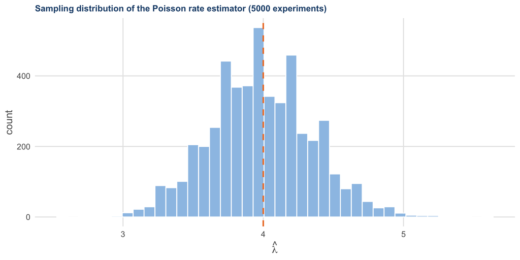

The cloud of 5000 estimates centers on the truth (orange) — its spread *is* the variance, and bias/MSE are read straight off it.

## Discussion: two estimators for the same parameter

**Pause.** For a Poisson($\lambda$), recall a special fact: $E(X)=\lambda$ **and** $\text{Var}(X)=\lambda$. So *both* of these estimate $\lambda$:
$$\hat\lambda_1 = \bar x = \frac1n\sum_i x_i \qquad\text{and}\qquad \hat\lambda_2 = \frac{1}{n-1}\sum_i (x_i-\bar x)^2.$$

Which one would you trust? How do you decide?

Both are reasonable and (nearly) unbiased — so the tie-breaker is **variance / MSE**. And we already know how to measure MSE: simulate.

## Demo: compare the two estimators — the code

```r
library(ggplot2)
set.seed(9)
true_lambda <- 4; n <- 30; m <- 5000

est <- replicate(m, {
  x <- rpois(n, true_lambda)
  c(mean = mean(x), variance = var(x))      # two competing estimators of lambda
})
l1 <- est["mean", ]; l2 <- est["variance", ]

mse <- function(est, theta) c(bias = mean(est) - theta,
                              variance = var(est),
                              mse = mean((est - theta)^2))
round(rbind(lambda_hat_mean = mse(l1, true_lambda),
            lambda_hat_var  = mse(l2, true_lambda)), 4)
```

```
                   bias variance    mse
lambda_hat_mean  0.0007   0.1289 0.1288
lambda_hat_var  -0.0074   1.2484 1.2482
```

Compare the MSE of $\hat\lambda_1=\bar x$ against $\hat\lambda_2=$ sample variance. Their sampling distributions are on the next slide.

## Demo: compare the two estimators — the result

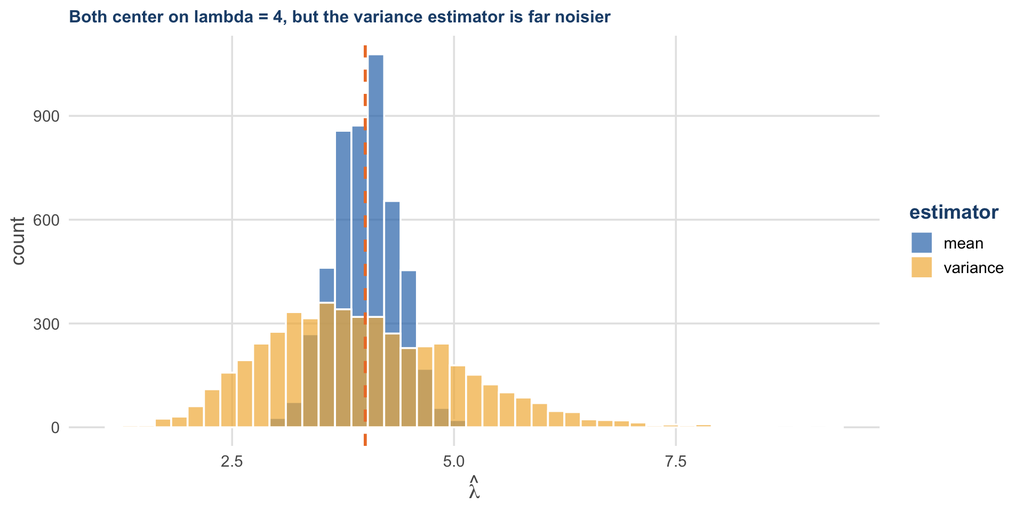

Both are roughly unbiased, but $\hat\lambda_1=\bar x$ has **much smaller MSE**. **Unbiasedness is not enough, variance is the tie-breaker, and Monte Carlo measured it for us.**

## Confidence interval coverage

A 95% CI promises to contain the true parameter 95% of the time **across repeated experiments**. We can *check* that promise by Monte Carlo.

Generate $m$ synthetic datasets, build a CI from each:
$$\big(\hat\theta_\ell^{(1)},\hat\theta_u^{(1)}\big),\dots,\big(\hat\theta_\ell^{(m)},\hat\theta_u^{(m)}\big),$$
then estimate coverage as the fraction that actually trap $\theta$:
$$\widehat{\text{coverage}} = \frac{1}{m}\sum_{j=1}^m \mathbf{1}\big\{\hat\theta_\ell^{(j)} < \theta < \hat\theta_u^{(j)}\big\}.$$

$\widehat{\text{coverage}}$ is itself a Monte Carlo estimate — it has a standard error, so we can tell whether a CI is honest.

## Demo: is the interval honest?

```r
set.seed(6)
true_lambda <- 4
n  <- 30
m  <- 10000

# For each simulated dataset: estimate lambda, build an approx 95% CI, check coverage
covered <- replicate(m, {
  x   <- rpois(n, true_lambda)
  lh  <- mean(x)
  se  <- sqrt(lh / n)                    # SE for a Poisson rate estimate
  ci  <- lh + c(-1.96, 1.96) * se
  ci[1] < true_lambda & true_lambda < ci[2]
})

coverage    <- mean(covered)
coverage_se <- sd(covered) / sqrt(m)     # Monte Carlo error of the coverage itself
round(c(coverage = coverage, mc_se = coverage_se, nominal = 0.95), 4)
```

```
coverage    mc_se  nominal
  0.9515   0.0021   0.9500
```

Coverage lands near the promised 0.95, and the Monte Carlo standard error tells us whether any gap is **real or just simulation noise**. (At small $n$ this normal-approximation CI tends to under-cover slightly — try $n=10$.)

## Monte Carlo for hypothesis testing

A test can be right or wrong in two ways:

|  | $H_0$ true | $H_0$ false |
| --- | --- | --- |
| **Reject $H_0$** | Type I error ($\alpha$) | Power ($1-\beta$) |
| **Fail to reject $H_0$** | Correct ($1-\alpha$) | Type II error ($\beta$) |

The same simulate-from-a-model recipe lets us *measure* the error rate and power — **Type I error** and **power**:

- **Type I error** ($\alpha$): simulate data under the null $H_0$, run the test, record the fraction of false rejections.
- **Power** ($1-\beta$): simulate data under a specific alternative $H_a$, record the fraction of correct rejections.

Both are, yet again, **averages of indicators**: $\widehat\alpha = \frac1m\sum_j \mathbf 1\{\text{reject on null dataset } j\}$. If you can simulate the experiment, you can measure how your test behaves.

# Part 5 — The Bootstrap

WHEN YOU DON’T KNOW THE CDF

## The plug-in idea

We observe $x_1,\dots,x_n \sim F$ with $F$ **unknown**, and want the sampling behavior of $\hat\theta=S(x_1,\dots,x_n)$.

**Bootstrap principle.** Replace the unknown $F$ by the **empirical cdf** $\hat F$ — the distribution placing mass $1/n$ on each observed $x_i$. Then “resample from $\hat F$” just means **sample the data with replacement**.

- $\hat F \to F$ as $n\to\infty$, so $\hat F$ is a reasonable stand-in.
- Sampling from $\hat F$ is trivial: draw $n$ values with replacement from $\{x_1,\dots,x_n\}$.

## Bootstrap estimate of bias

Given data and $\hat\theta=S(x_1,\dots,x_n)$, estimate $\text{Bias}(\hat\theta)$:

- Draw $B$ bootstrap samples, each by resampling the data with replacement $n$ times:
  - $x_{11}^*,\dots,x_{1n}^* \;\leftarrow$ sample 1
  - $\;\;\vdots$
  - $x_{B1}^*,\dots,x_{Bn}^* \;\leftarrow$ sample $B$
- Recompute the statistic on each: $\hat\theta^{*(b)}=S(x_{b1}^*,\dots,x_{bn}^*)$.
- Average: $\bar\theta^{*}=\frac1B\sum_{b=1}^B \hat\theta^{*(b)}\;\approx\;E(\hat\theta)$.
- Estimate bias: $\;\widehat{\text{Bias}} = \bar\theta^{*} - \hat\theta_{\text{obs}}$.

## Demo: bootstrapping a Poisson rate — the code

```r
library(ggplot2)
set.seed(1)
n      <- 200
lambda <- 5
x_obs  <- rpois(n, lambda)              # our ONE observed dataset

lambda_hat <- mean(x_obs)               # estimate from the observed data

B <- 5000
boot_means <- replicate(B, mean(sample(x_obs, n, replace = TRUE)))

boot_summary <- c(
  observed_est = lambda_hat,
  boot_mean    = mean(boot_means),
  boot_bias    = mean(boot_means) - lambda_hat,
  boot_se      = sd(boot_means)          # bootstrap standard error
)
round(boot_summary, 4)
```

```
observed_est    boot_mean    boot_bias      boot_se
      5.1050       5.1070       0.0020       0.1441
```

Resample the one observed dataset with replacement $B=5000$ times, recomputing the mean each time. The bootstrap distribution is on the next slide.

## Demo: bootstrapping a Poisson rate — the result

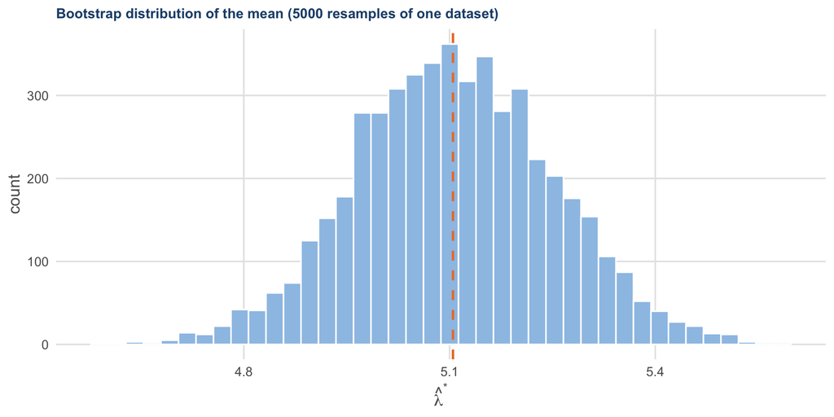

From a **single** dataset, resampling with replacement reconstructs the sampling distribution of $\hat\lambda$ — handing us a standard error and a bias estimate for free.

## Bootstrap confidence interval

The bootstrap distribution also gives a CI with no formula required:

**Percentile interval.** Take the 2.5th and 97.5th percentiles of the bootstrap estimates $\{\hat\theta^{*(b)}\}$:
$$\Big(\,\hat\theta^{*}_{(2.5\%)},\ \hat\theta^{*}_{(97.5\%)}\,\Big).$$

```r
quantile(boot_means, c(0.025, 0.975))
```

```
 2.5% 97.5%
4.825 5.390
```

# Part 6 — Wrap-up

SIMPLE IDEA, MANY APPLICATIONS

## Key Themes

**The single engine**

- LLN: sample averages → expectations
- CLT: error bars of size $\sigma/\sqrt{n}$
- A probability is an expectation of an indicator

**Where we pointed it**

- Integration: average $h(X_i)$
- Rare events: importance sampling
- Inference: simulate datasets → bias, MSE, coverage, power
- Unknown $F$: bootstrap (resample the data)

Everything today was **“if you can sample, you can compute”** plus the discipline of **always reporting a Monte Carlo standard error**.

## Additional exercises if we’re done early

- **Estimate $\pi$.** Draw points uniformly in the unit square; the fraction inside the quarter circle estimates $\pi/4$. Report your estimate with a Monte Carlo standard error.
- **Lady tasting tea.** Simulate $n=10$ trials under $H_0: p=1/2$. How often does a friend who is *guessing* get $\ge 8$ correct? That fraction is a Monte Carlo $p$-value.
- **Coverage under misspecification.** Redo the CI-coverage demo but generate data from a distribution *other* than the one your CI assumes. Does coverage still hold?
- **Bootstrap a median.** Bootstrap a 95% percentile interval for the median of a skewed sample. Why is there no easy closed-form SE here?

# Appendix — Exercise Solutions

WORKED ANSWERS

## Solution 1: estimate $\pi$

Draw points in the unit square; the fraction inside the quarter circle estimates $\pi/4$, so $\hat\pi = 4\hat p$.

```r
set.seed(1)
N      <- 1e6
x <- runif(N); y <- runif(N)
inside <- (x^2 + y^2) <= 1            # in the quarter circle?
pi_hat <- 4 * mean(inside)
se     <- 4 * sd(inside) / sqrt(N)    # Monte Carlo standard error
round(c(pi_hat = pi_hat, se = se, truth = pi), 4)
```

```
pi_hat     se  truth
3.1437 0.0016 3.1416
```

## Solution 2: lady tasting tea ($p$-value)

Under $H_0$ the friend is guessing, $X \sim \text{Binomial}(10, 0.5)$. The $p$-value is $P(X \ge 8)$.

```r
set.seed(2)
m <- 1e5
k <- rbinom(m, size = 10, prob = 0.5)              # correct calls if purely guessing
round(c(mc_p_value = mean(k >= 8),
        exact      = pbinom(7, 10, 0.5, lower.tail = FALSE)), 4)
```

```
mc_p_value      exact
    0.0558     0.0547
```

$p \approx 0.055$ (matches the exact binomial). Getting 8/10 is only *borderline* evidence of real ability — under pure guessing it happens about 1 in 18 times.

## Solution 3: coverage under misspecification

Our CI assumes Poisson ($\text{SE}=\sqrt{\hat\lambda/n}$). Generate **over-dispersed** data instead (variance $>$ mean) and watch coverage fall.

```r
set.seed(3)
true_mean <- 4; n <- 30; m <- 10000
covered <- replicate(m, {
  x  <- rnbinom(n, mu = true_mean, size = 2)   # negative binomial: var > mean
  lh <- mean(x)
  se <- sqrt(lh / n)                           # the (wrong) Poisson SE
  ci <- lh + c(-1.96, 1.96) * se
  ci[1] < true_mean & true_mean < ci[2]
})
round(c(coverage = mean(covered), nominal = 0.95), 3)
```

```
coverage  nominal
    0.74     0.95
```

Coverage drops well below 0.95: the Poisson SE *understates* the real variability. **A CI is only as good as the model its SE assumes.**

## Solution 4: bootstrap a median

Resample a skewed sample with replacement; take percentiles of the bootstrap medians.

```r
set.seed(4)
x <- rexp(80, rate = 0.2)                         # skewed sample
boot_med <- replicate(5000, median(sample(x, length(x), replace = TRUE)))
round(c(median  = median(x),
        ci_lo   = unname(quantile(boot_med, 0.025)),
        ci_hi   = unname(quantile(boot_med, 0.975))), 3)
```

```
median  ci_lo  ci_hi
 3.522  2.547  4.186
```

The percentile interval comes straight off the bootstrap medians. There is no easy closed-form SE because the median’s sampling variance depends on the **density at the median**, $f(m)$, which we don’t know — the bootstrap sidesteps it entirely.